[figure not shown]

Ana Paula Pacca da Silva

# NOS Business Case

## Import dataset

```r
# Load required library
library(readr)

# URL of the CSV file
url <- 'https://raw.githubusercontent.com/anapaccasilva/NOS-case/main/Base_Cliente.csv'

# Read the CSV file
customers <- read.csv2(url)

# Remove special characters
colnames(customers) <- gsub("'", "", iconv(colnames(customers), from = "UTF-8", to='ASCII//TRANSLIT'))
customers[] <- lapply(customers, function(x) gsub("'", "", iconv(x, from = "UTF-8", to = "ASCII//TRANSLIT")))

print ('Data imported')
```

```
## [1] "Data imported"
```

# **EDA - Exploratory Data Analysis**

## 1) Overview

```r
# Get the dimensions of the data frame 'customers'
shape_customers <- dim(customers)

# Print the dimensions
print(shape_customers)
```

```
## [1] 88737    13
```

```r
str(customers)
```

```
## 'data.frame':    88737 obs. of  13 variables:
##  $ CAL_MONTH_ID              : chr  "202207" "202207" "202207" "202207" ...
##  $ cliente                   : chr  "931323730" "875322903" "14142089" "71374939" ...
##  $ Segmento                  : chr  "MASS BUSINESS" "MASS BUSINESS" "MASS BUSINESS" "MASS BUSINESS" ...
##  $ Ultimo_Movimento          : chr  "Base" "Base" "Gross Add" "Base" ...
##  $ Segmento_Oferta           : chr  "SO FIXO SEM TV" "CONVERGENTE 4P/5P" "SO FIXO BASE TV" "CONVERGENTE 4P/5P" ...
##  $ Canal_Prioritario         : chr  "C1" "C1" "C11" "C2" ...
##  $ CONCELHO                  : chr  "TONDELA" "SANTA MARIA DA FEIRA" "GONDOMAR" "VILA VERDE" ...
##  $ DISTRITO                  : chr  "VISEU" "AVEIRO" "PORTO" "BRAGA" ...
##  $ Produto_nao_Telco         : chr  "Nao" "Nao" "Nao" "Nao" ...
##  $ Periodo_Fidelizacao       : chr  "-38" "18" "24" "16" ...
##  $ Quantida_Produtos_Contrato: chr  "1" "4" "3" "7" ...
##  $ mensalidade_liquida       : chr  "13.88" "41.15" "29.26" "73.72" ...
##  $ Atividade.Economica..INE. : chr  "G - Comercio por grosso e a retalho; reparacao de veiculos automoveis e motociclos" "C - Industrias transformadoras" "I - Alojamento, restauracao e similares" "G - Comercio por grosso e a retalho; reparacao de veiculos automoveis e motociclos" ...
```

## 2) Understanding of the variables

`Categorical Variables`

- ultimo_movimento
- segmento_oferta
- canal_prioritário
- concelho
- distrito
- Produto_nao_Telco
- atividade_economica (INE)

**Barplot**

```r
# Install and load required libraries
# install.packages(c("dplyr", "ggplot2"))
# install.packages("scales")


library(dplyr)
library(ggplot2)
library(scales)
```

Vertical Chart

```r
# Function to create a bar plot with labels, dot as a thousand separator, and centered title
barplot_count <- function(dataframe, variable, title) {
  variable <- enquo(variable)

  df <- dataframe %>% group_by(!!variable) %>% summarize(count = n())
  total <- sum(df$count)
  df$percent <- df$count / total * 100  # Calculate relative percentage

  # Arrange the data frame in descending order of count
  df <- df %>% arrange(desc(count))

  # Randomly select one color from the specified list
  random_color <- sample(c('#4B5DA5', '#D486B8', '#67C1B5', '#6EA530', '#FADC08', '#E24232'), 1)

  # Create a bar plot with the randomly selected color
  p <- ggplot(df, aes(x = factor(!!variable, levels = .data[[quo_name(variable)]]), y = count)) +
    geom_bar(stat = "identity", color = "black", fill = random_color) +
    theme_minimal() +
    theme(legend.position = "none",
          plot.title = element_text(hjust = 0.5)) +  # Center the title
    labs(title = title, x = quo_name(variable), y = "quantidade") +
    theme(panel.grid = element_blank(),
          axis.text.x = element_text(angle = 45, hjust = 1),
          panel.border = element_rect(color = "black", fill = NA),
          plot.background = element_rect(fill = NA),
          legend.background = element_rect(fill = NA))

  # Add smaller labels to the columns with a dot as a thousand separator
  p <- p + geom_text(aes(label = sprintf("%s\n%.2f%%", comma(count), percent)),
                     position = position_stack(vjust = 0.5), size = 2)

  # Save the plot as a PNG file
  ggsave(paste0(title, "_ordered.png"), plot = p, device = "png", width = 8, height = 6, dpi = 300)

  # Print the plot
  print(p)
}
```

Horizontal Chart

```r
# Function to create a horizontal bar plot with labels (count values), dot as a thousand separator, and centered title
barplot_count_horizontal <- function(dataframe, variable, title) {
  variable <- enquo(variable)

  df <- dataframe %>% group_by(!!variable) %>% summarize(count = n())
  total <- sum(df$count)

  # Randomly select one color from the specified list
  random_color <- sample(c('#4B5DA5', '#D486B8', '#67C1B5', '#6EA530', '#FADC08', '#E24232'), 1)

  # Create a horizontal bar plot with the randomly selected color
  p <- ggplot(df, aes(x = count, y = reorder(!!variable, count))) +
    geom_bar(stat = "identity", color = "black", fill = random_color) +
    geom_text(aes(label = comma(count), x = count),
              position = position_stack(vjust = 0.5), size = 2, hjust = -0.2) +  # Adjust hjust for label position
    theme_minimal() +
    theme(legend.position = "none",
          plot.title = element_text(hjust = 0.5)) +  # Center the title
    labs(title = title, x = "quantidade", y = quo_name(variable)) +
    theme(panel.grid = element_blank(),
          axis.text.y = element_text(hjust = 0),
          panel.border = element_rect(color = "black", fill = NA),
          plot.background = element_rect(fill = NA),
          legend.background = element_rect(fill = NA))

  # Save the plot as a PNG file
  ggsave(paste0(title, "_horizontal.png"), plot = p, device = "png", width = 8, height = 6, dpi = 300)

  # Print the plot
  print(p)
}
```

# Analysis

*To understand the categorical variables, some bar charts are presented below. The function used includes assigning random colors within the NOS palette to make data visualizations more pleasant and less monotonous.*

▶ Ultimo_Movimento

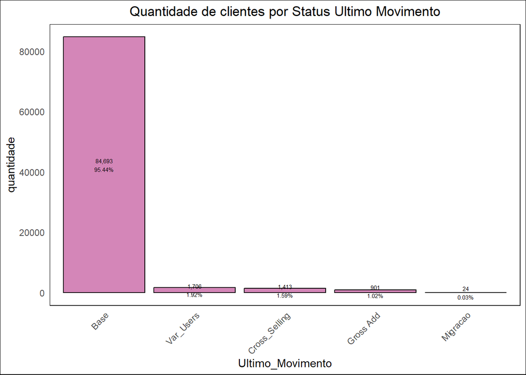

```r
barplot_count(customers, Ultimo_Movimento, "Quantidade de clientes por Status Ultimo Movimento")
```

▶ Segmento_Oferta

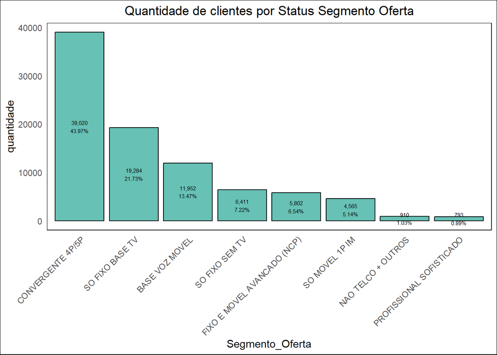

```r
barplot_count(customers, Segmento_Oferta, "Quantidade de clientes por Status Segmento Oferta")
```

▶ Canal_Prioritario

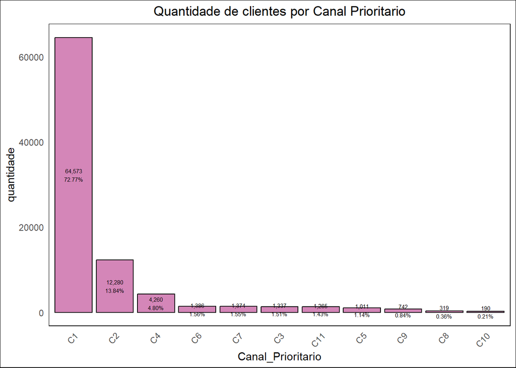

```r
barplot_count(customers, Canal_Prioritario, "Quantidade de clientes por Canal Prioritario")
```

▶ CONCELHO

```r
# getting unique values into a data frame
conc_df <- as.data.frame(table(customers$CONCELHO))

# Rename the columns for clarity
colnames(conc_df) <- c("CONCELHO", "Count")

# Order the data frame by Count in descending order
conc_df <- conc_df[order(-conc_df$Count), ]

# Display the resulting data frame
print(conc_df)
```

```
##                        CONCELHO Count
## 122                      LISBOA 10015
## 207                       PORTO  3635
## 250                      SINTRA  3217
## 65                      CASCAIS  2764
## 286           VILA NOVA DE GAIA  2652
## 139                  MATOSINHOS  2088
## 173                      OEIRAS  2055
## 124                      LOURES  1936
## 17                       ALMADA  1903
## 52                        BRAGA  1869
## 172                    ODIVELAS  1613
## 113                   GUIMARAES  1598
## 25                      AMADORA  1481
## 109                    GONDOMAR  1399
```

[output cut: 285 more lines]

▶ DISTRITO

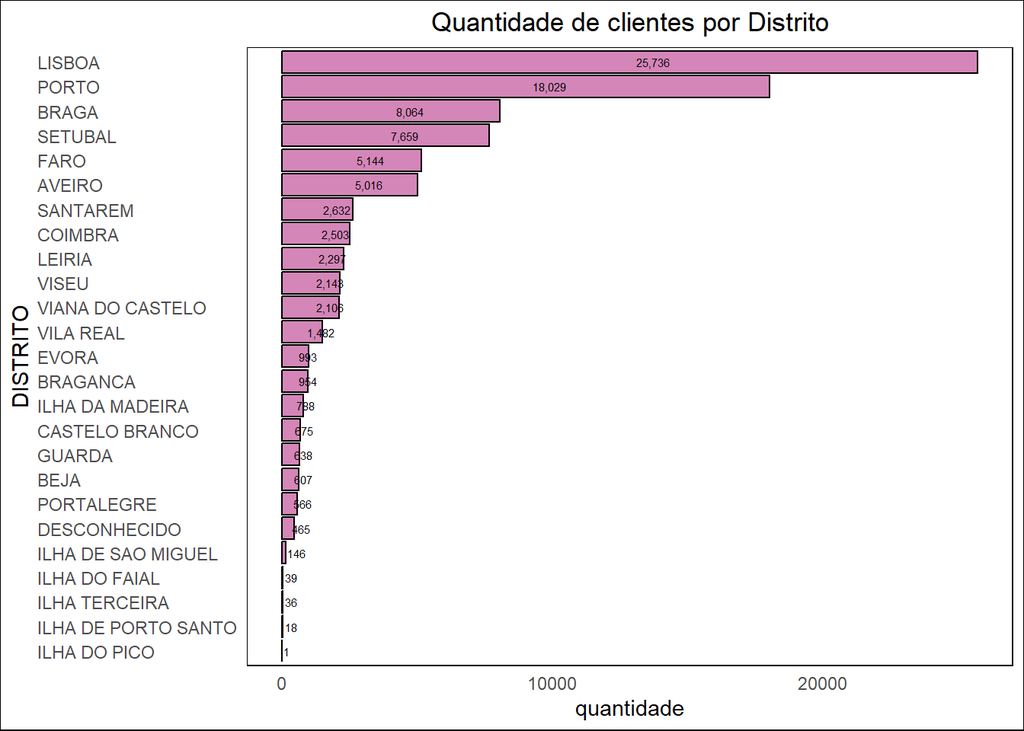

```r
barplot_count_horizontal(customers, DISTRITO, "Quantidade de clientes por Distrito")
```

`Numerical Variables`

- Periodo_Fidelização
- Quantida_Produtos_Contrato
- mensalidade_liquida

```r
# Set these variables as numerics
customers <- mutate(customers,
                    Periodo_Fidelizacao = as.numeric(Periodo_Fidelizacao),
                    Quantida_Produtos_Contrato = as.numeric(Quantida_Produtos_Contrato),
                    mensalidade_liquida = as.numeric(mensalidade_liquida))
```

# Analysis

*To understand the numerical variables, some histograms are presented below, representing the distribution of the data, and when necessary, descriptive statistical analysis. The function used includes the assignment of random colors to make data visualizations more pleasant and less monotonous.*

**Histogram**

```r
# Function to create a histogram with a random fill color
histogram_custom <- function(dataframe, variable, title) {
  # Randomly select one fill color
  random_fill_color <- sample(c('#4B5DA5', '#D486B8', '#67C1B5', '#6EA530', '#FADC08', '#E24232'), 1)

    # Filter out missing values and frequency less than 10
  dataframe <- dataframe %>%
    filter(!is.na(!!enquo(variable))) %>%
    group_by(!!enquo(variable)) %>%
    filter(n() >= 10)


  # Create a histogram with the randomly selected fill color
  ggplot(dataframe, aes(x = !!enquo(variable))) +
    geom_histogram(fill = random_fill_color, color = "black", alpha = 0.8, bins = 30) +
    theme_minimal() +
    labs(title = title) +
    theme(panel.grid = element_blank(),
          axis.text.x = element_text(angle = 45, hjust = 1),
          panel.border = element_rect(color = "black", fill = NA),
          plot.background = element_rect(fill = NA),
          plot.title = element_text(hjust = 0.5))  # Center the title
}
```

▶ Periodo_Fidelizacao

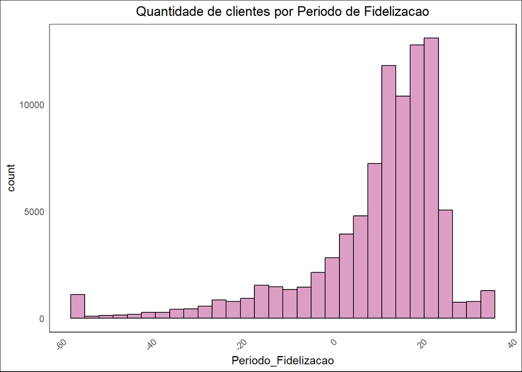

```r
histogram_custom(customers, `Periodo_Fidelizacao`, "Quantidade de clientes por Periodo de Fidelizacao")
```

▶ Quantida_Produtos_Contrato

```r
summary(customers$Quantida_Produtos_Contrato)
```

```
##     Min.  1st Qu.   Median     Mean  3rd Qu.     Max.
##    1.000    3.000    5.000    5.819    7.000 5980.000
```

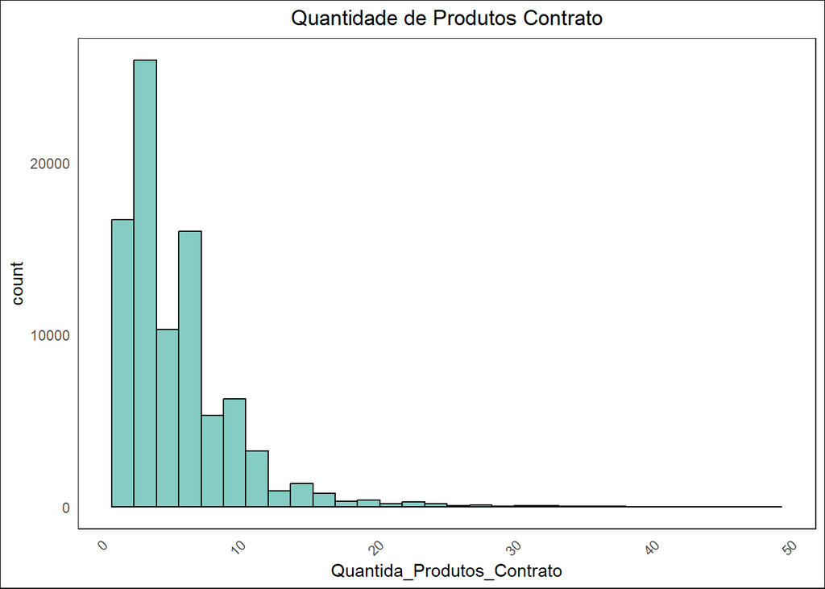

```r
histogram_custom(customers, `Quantida_Produtos_Contrato`, "Quantidade de Produtos Contrato")
```

▶ mensalidade_liquida

```r
summary(customers$mensalidade_liquida)
```

```
##    Min. 1st Qu.  Median    Mean 3rd Qu.    Max.
##  -60.00   28.82   55.98   72.25   90.21 5405.46
```

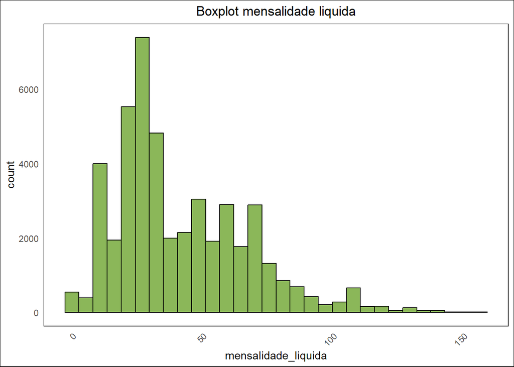

```r
histogram_custom(customers, `mensalidade_liquida`, "Boxplot mensalidade liquida")
```

`Incremental Variable`

# Analysis

*As the chosen hypothesis, we decided to analyze the possibility of offering more products to those customers whose contracts involve 5 or fewer products. To proceed with the proposed analysis, a conditional variable was created that indicates whether the customer has more than 5 products in the contract or not.*

```r
# Create a new column 'multiplos_produtos' based on the condition
customers <- customers %>% mutate(multiplos_produtos = ifelse(Quantida_Produtos_Contrato > 5, 1, 0))
```

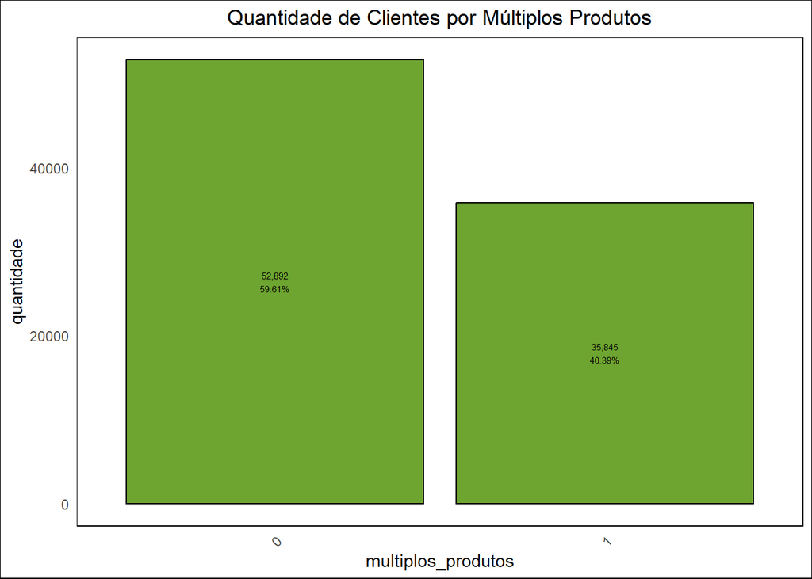

```r
barplot_count(customers, multiplos_produtos, "Quantidade de Clientes por Múltiplos Produtos")
```

## 3) Relationship between variables

# Analysis

*Finally, to understand how the numerical variables relate to each other, some stacked graphs and boxplots were constructed for the variable under analysis (multiple products) and the variables that showed some level of correlation with it.*

**Stacked Bar function**

```r
# Function to create a stacked bar plot with labels
stacked_bar <- function(dataframe, X, Y, title) {
  colors <- c('#4B5DA5', '#D486B8', '#67C1B5', '#6EA530', '#FADC08', '#E24232')

  cross_tab <- table(dataframe[[Y]], dataframe[[X]])
  cross_tab_prop <- prop.table(cross_tab, margin = 1)

  df <- as.data.frame(cross_tab_prop)

  # Create a stacked bar plot
  p <- ggplot(df, aes(x = Var1, y = Freq, fill = Var2)) +
    geom_bar(stat = "identity", color = "black") +
    theme_minimal() +
    labs(title = title, x = X, y = "Proportion") +
    scale_fill_manual(values = c("#414141", sample(colors, nlevels(df$Var2), replace = TRUE))) +  # Randomly assign colors
    theme(panel.grid = element_blank(),
          panel.border = element_rect(color = "black", fill = NA),
          plot.background = element_rect(fill = NA),
          plot.title = element_text(hjust = 0.5),  # Center the title
          axis.text.x = element_text(angle = 90, vjust = 0.5, hjust=0))  # Rotate x-axis labels


  # Add labels to the stacked bars
  p <- p + geom_text(aes(label = scales::percent(Freq, accuracy = 0.01)),
                     position = position_stack(vjust = 0.5), size = 2)

  # Print the plot
  print(p)
}
```

**Boxplot**

```r
# Function to create a boxplot
boxplot_custom <- function(dataframe, X, Y, title) {
  # Select a color randomly from the list of acceptable colors for this type of plot
  colors <- c('#4B5DA5', '#D486B8', '#67C1B5', '#6EA530', '#4B5DA5', '#FADC08', '#E24232')

  # Create a boxplot using ggplot2
  p <- ggplot(dataframe, aes(x = !!sym(X), y = !!sym(Y), group = !!sym(X))) +
    geom_boxplot(fill = sample(c("#414141", colors), 1), color = "black", width = 0.5, outlier.shape = NA) +
    theme_minimal() +
    labs(title = title, x = X, y = Y) +
    theme(panel.grid = element_blank(),
          panel.border = element_rect(color = "black", fill = NA),
          plot.background = element_rect(fill = NA),
          plot.title = element_text(hjust = 0.5),  # Center the title
          axis.text.x = element_text(angle = 0, hjust = 0.5))  # Horizontal x-axis labels


  # Print the plot
  print(p)
}
```

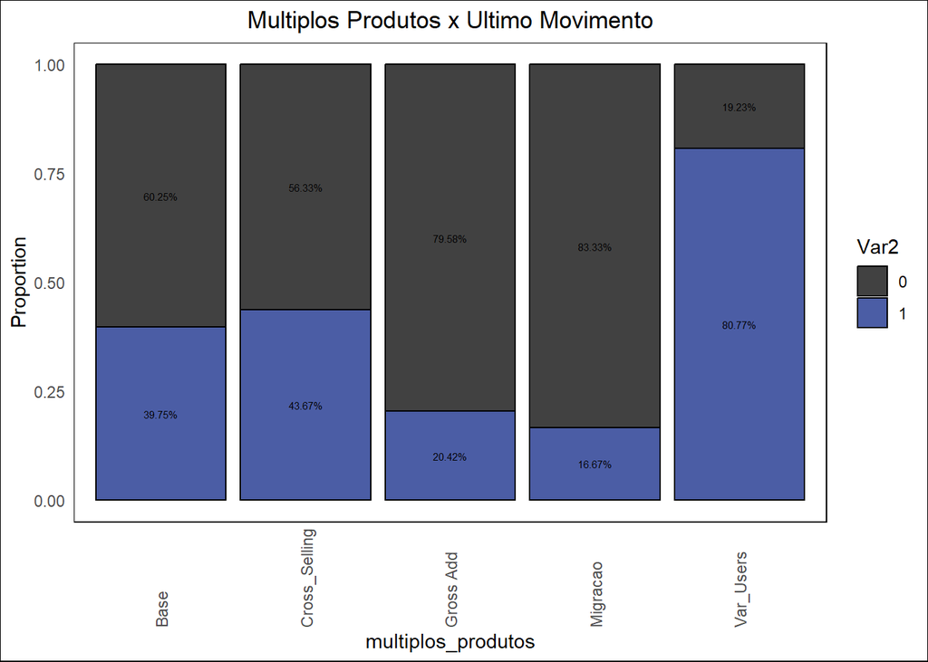

```r
stacked_bar(customers, "multiplos_produtos", "Ultimo_Movimento", 'Multiplos Produtos x Ultimo Movimento')
```

▶ Multiplos Produtos x Canal Prioritário

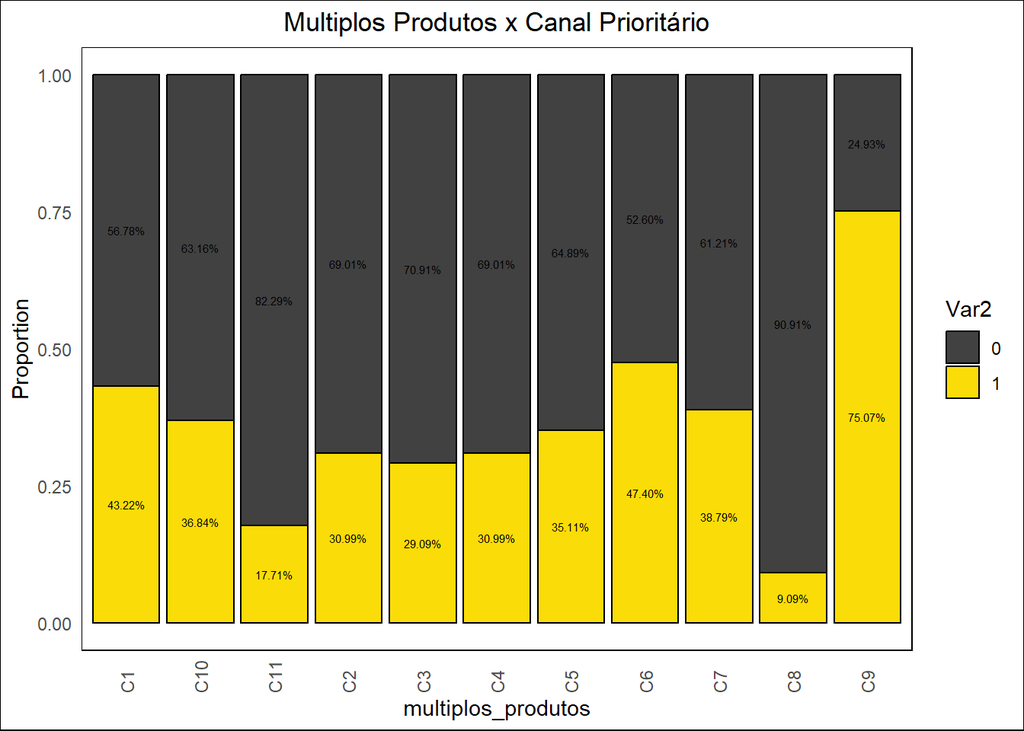

```r
stacked_bar(customers, "multiplos_produtos", "Canal_Prioritario", 'Multiplos Produtos x Canal Prioritário')
```

▶ Multiplos Produtos x Distrito

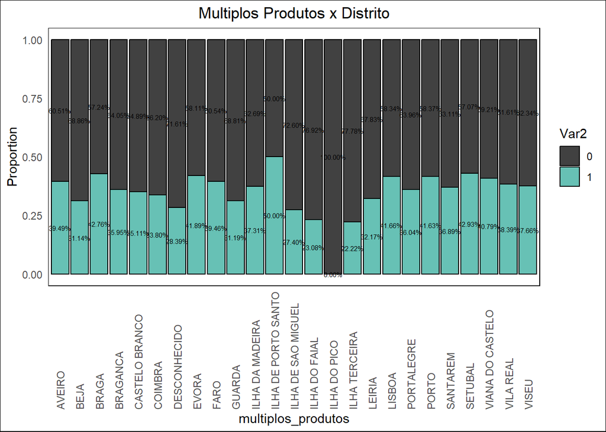

```r
stacked_bar(customers, "multiplos_produtos", "DISTRITO", 'Multiplos Produtos x Distrito')
```

▶ Múltiplos Produtos x Periodo Fidelização

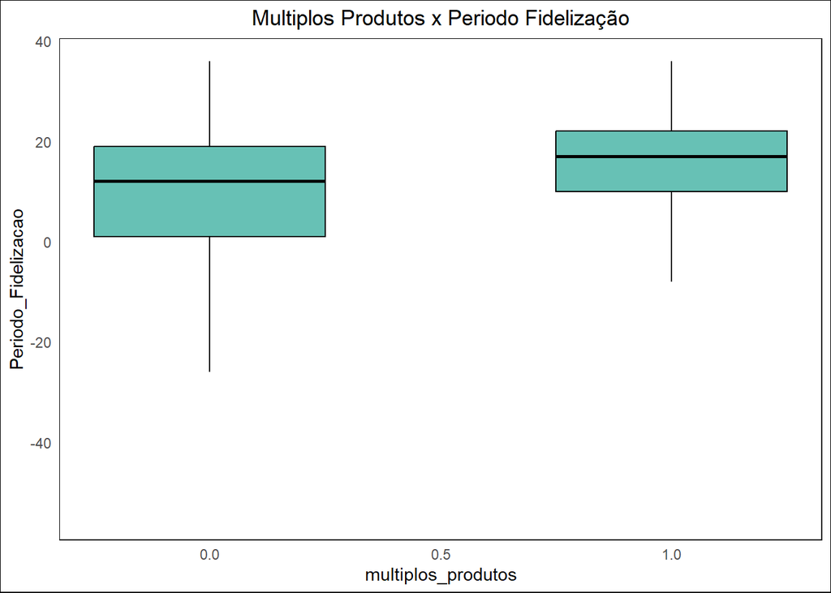

```r
boxplot_custom(customers, "multiplos_produtos", "Periodo_Fidelizacao", 'Multiplos Produtos x Periodo Fidelização')
```